# Análise Exploratória

# Análise Exploratória

A Análise Exploratória é uma fase importante de uma tarefa de Ciência de Dados. É nesta fase que buscamos entender os dados com os seguintes objetivos:

- Identificar padrões iniciais
- Formular perguntas de pesquisa e hipóteses
- Identificar dados incompletos ou não confiáveis

Para atingir os objetivos, em geral usa-se uma combinação de análises estatísticas com uma grande ênfase em geração e interpretação de gráficos.

## Leitura e análise inicial dos dados

```r
#importação de bibliotecas
library(dplyr)

# lê o arquivo CSV
df <- read.csv('../data/aluguel.csv', header = T, sep=",", stringsAsFactors=FALSE)
```

O primeiro passo ao se analisar dados desconhecidos é visualizar algumas linhas de dados:

```r
head(df, 10)
```

```
##    codigo                       endereco quartos suite area vaga aluguel
## 1      34   Rua Desembargador Westphalen       2     0   90    0     900
## 2     167              Rua Jose Loureiro       2     0   64    0     650
## 3    6784              Rua Jose Loureiro       2     0   81    0    1100
## 4      82             Rua Lourenço Pinto       2     0   50    0    1350
## 5    2970             Rua Lourenço Pinto       2     0   63    0    1300
## 6   34197          Alameda Doutor Muricy       2     0   80    1     900
## 7    5072          Alameda Doutor Muricy       2     0   84    0    1100
## 8     469   Rua Desembargador Westphalen       1     0   30    0     550
## 9      24   Rua Desembargador Westphalen       1     0   60    1     800
## 10     74 Avenida Visconde de Guarapuava       2     1  132    1    1800
##    condominio     data
## 1         371 11/10/17
## 2         428 15/07/17
## 3         400 23/08/17
## 4         300 19/09/17
## 5         300 05/08/17
## 6         410 23/10/17
## 7         382 02/09/17
## 8         210 03/07/17
## 9         120 30/09/17
## 10        520 12/10/17
```

A função `summary()` é útil para se ter uma idéia de estatísticas básicas para as variáveis numéricas. Por exemplo, abaixo podemos ver que a média dos valores de aluguel é 898 enquanto a mediana é 900.

```r
summary(df)
```

```
##      codigo           endereco            quartos        suite
##  Min.   :    24.0   Length:20          Min.   :1.0   Min.   :0.00
##  1st Qu.:   145.8   Class :character   1st Qu.:1.0   1st Qu.:0.00
##  Median :  4021.0   Mode  :character   Median :1.5   Median :0.00
##  Mean   : 31557.2                      Mean   :1.5   Mean   :0.05
##  3rd Qu.: 36848.5                      3rd Qu.:2.0   3rd Qu.:0.00
##  Max.   :294579.0                      Max.   :2.0   Max.   :1.00
##       area             vaga         aluguel       condominio
##  Min.   : 30.00   Min.   :0.00   Min.   : 550   Min.   :120.0
##  1st Qu.: 46.50   1st Qu.:0.00   1st Qu.: 600   1st Qu.:300.0
##  Median : 63.50   Median :0.00   Median : 900   Median :350.0
##  Mean   : 64.65   Mean   :0.35   Mean   : 898   Mean   :335.9
##  3rd Qu.: 80.00   3rd Qu.:1.00   3rd Qu.:1100   3rd Qu.:401.2
##  Max.   :132.00   Max.   :1.00   Max.   :1800   Max.   :520.0
##      data
##  Length:20
##  Class :character
##  Mode  :character
##
##
##
```

## Convertendo colunas para fatores (factors)

Para fazer uma análise exploratória adequada, é preciso que as colunas do DataFrame estejam com tipos adequados. Um tipo de dado importante no R é o **factor**, usado para variáveis categóricas com gênero, cor, idioma, etc. A decisão sobre quais variáveis devem ser consideradas fatores depende do problema em questão. No nosso caso, vamos converter a variável `vaga` para fator para que ela seja usada posteriormente.

```r
df$vaga <- as.factor(df$vaga)

str(df)
```

```
## 'data.frame':    20 obs. of  9 variables:
##  $ codigo    : int  34 167 6784 82 2970 34197 5072 469 24 74 ...
##  $ endereco  : chr  "Rua Desembargador Westphalen" "Rua Jose Loureiro" "Rua Jose Loureiro" "Rua Lourenço Pinto" ...
##  $ quartos   : int  2 2 2 2 2 2 2 1 1 2 ...
##  $ suite     : int  0 0 0 0 0 0 0 0 0 1 ...
##  $ area      : int  90 64 81 50 63 80 84 30 60 132 ...
##  $ vaga      : Factor w/ 2 levels "0","1": 1 1 1 1 1 2 1 1 2 2 ...
##  $ aluguel   : int  900 650 1100 1350 1300 900 1100 550 800 1800 ...
##  $ condominio: int  371 428 400 300 300 410 382 210 120 520 ...
##  $ data      : chr  "11/10/17" "15/07/17" "23/08/17" "19/09/17" ...
```

## Visualização da distribuição de variáveis

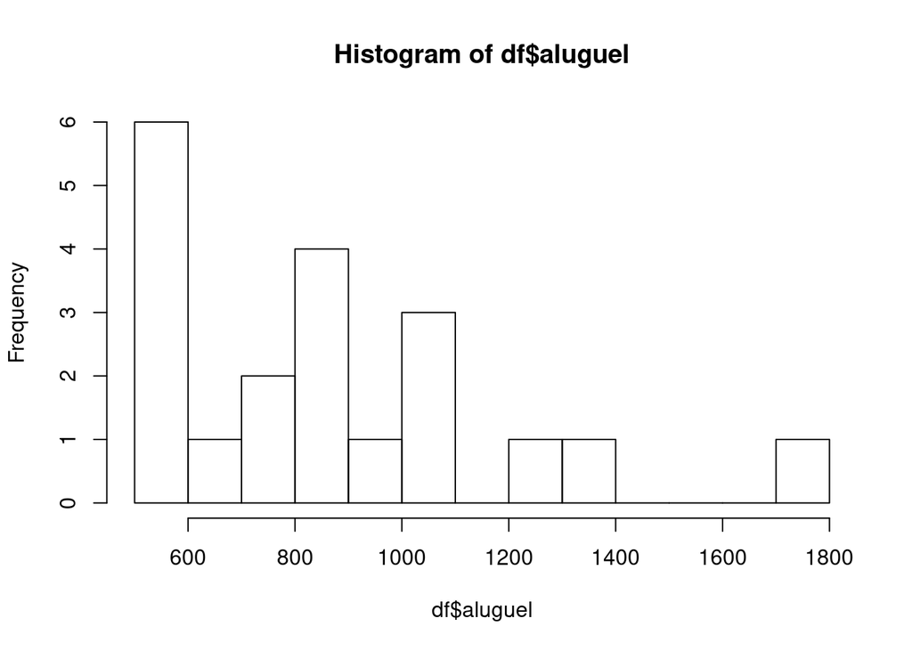

```r
# o parâmetro breaks determina o número de agrupamentos
hist(df$aluguel, breaks=10)
```

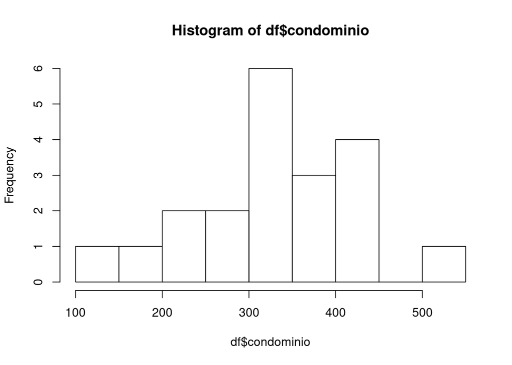

```r
hist(df$condominio, breaks=10)
```

Podemos usar gráficos de barras para mostrar a contagem de variáveis fatores. Por exemplo, abaixo mostramos o total de apartamentos sem (0) e com (1) vaga.

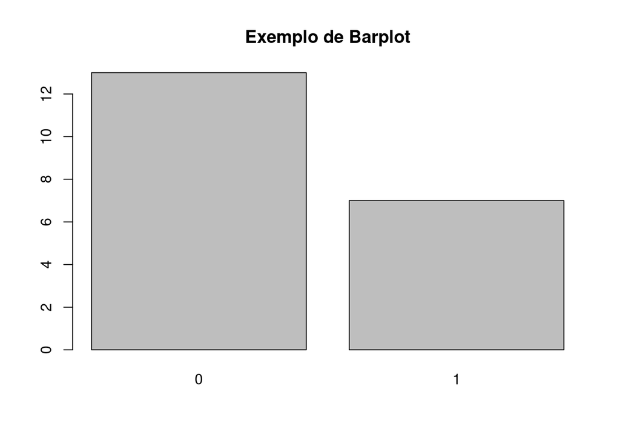

```r
plot(df$vaga, main = "Exemplo de Barplot")
```

O R também tem uma função dedicada para gráficos de barras. Abaixo usamos o função `barplot` para mostrar um gráfico com os apartamentos de 2 quartos e 1 vaga.

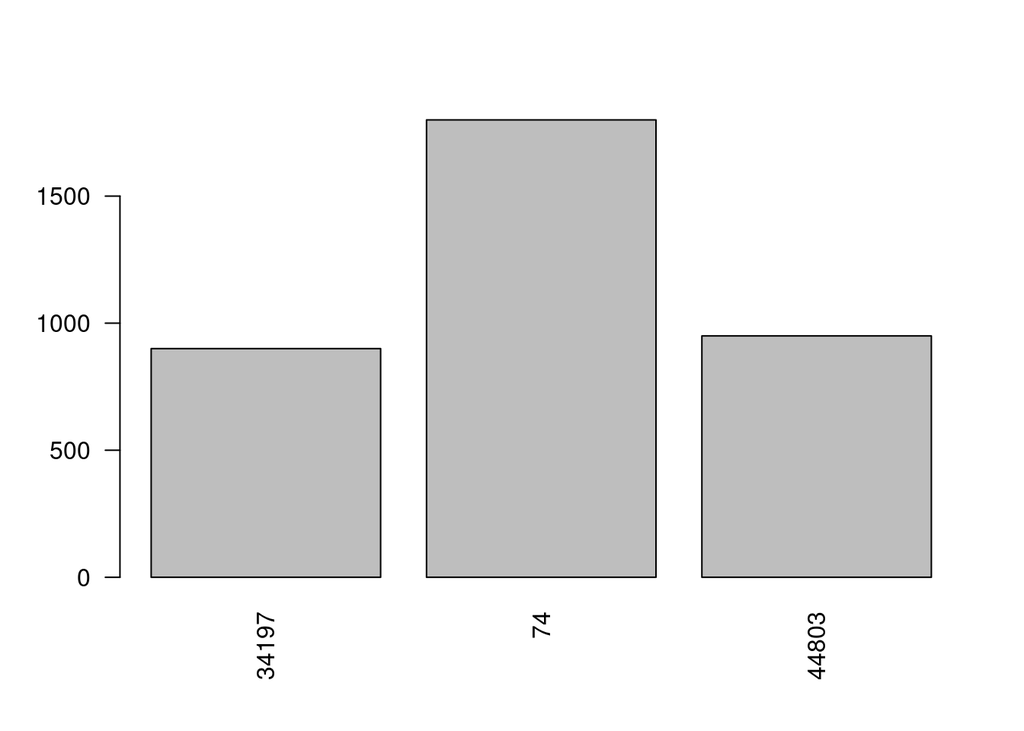

```r
df_bar <- df %>%
  filter(quartos == 2 & vaga == 1)

# o parâmetro las=2 faz as descrições serem mostradas na vertical
barplot(height=df_bar$aluguel, names=df_bar$codigo, las=2)
```

Outra forma de visualizar a distribuição de variáveis é através de Box Plots. Abaixo exibimos uma gráfico com os valores de aluguéis dependendo da variável vaga. Podemos perceber que a variação nos aluguéis é maior nos apartamentos sem vaga. Podemos ver também um outlier (círculo em cima da barra). Verifique os dados e identifique nos apartamentos com vaga qual apartamento tem este valor de aluguel tão diferente.

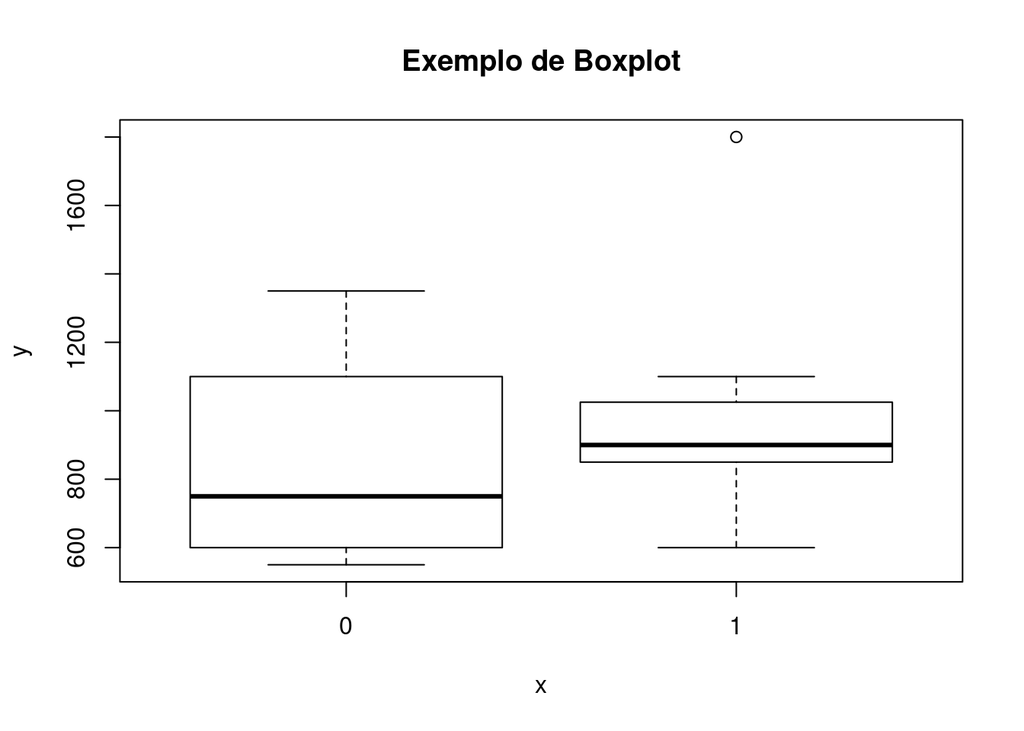

```r
plot(df$vaga, df$aluguel, main = "Exemplo de Boxplot")
```

## Análise da correlação entre as variáveis

Para identificar associações entre as variáveis podemos utilizar diversas ferramentas estatísticas e visuais. Para calcular a correlação (Pearson) entre todos os pares de variáves, podemos usar a função `cor`. Abaixo podemos ver que a maior correlação está entre a área do apartamento e o aluguel. Isto significa que, aparentemente, o tamanho do apartamento é o que mais influencia no valor total.

```r
df_corr <- df %>% select(area, aluguel, condominio)

cor(df_corr)
```

```
##                 area   aluguel condominio
## area       1.0000000 0.7481962  0.4666270
## aluguel    0.7481962 1.0000000  0.3024938
## condominio 0.4666270 0.3024938  1.0000000
```

Uma forma interessante de visualizar a matrix de correlações é usar um Heatmap. No caso abaixo usamos cores azuis para identificar as correlações maiores e cores vermelhas para as menores.

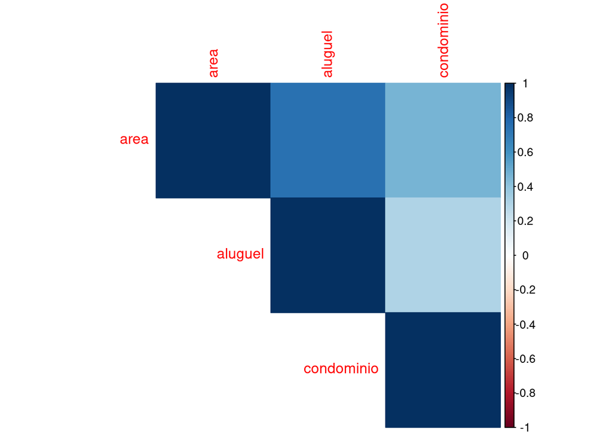

```r
library(corrplot)
corrplot(cor(df_corr),
  method = "color",
  type = "upper" # show only upper side
)
```

A correlação é uma boa medida de associação entre variáveis, mas ela não oferece detalhes sobre a distribuição ou sobre a presença de outliers. Para se ter uma ideia melhor das associações, é interessante visualizar os dados no plano cartesiano. Para isto podemos construir uma matriz com as visualizações dos pontos para todas as combinações de variáveis. Abaixo fazemos isto para área, aluguel e condomínio. Veja que entre aluguel e área há realmente uma tendência de associação (maior concentração de pontos próximos à diagonal).

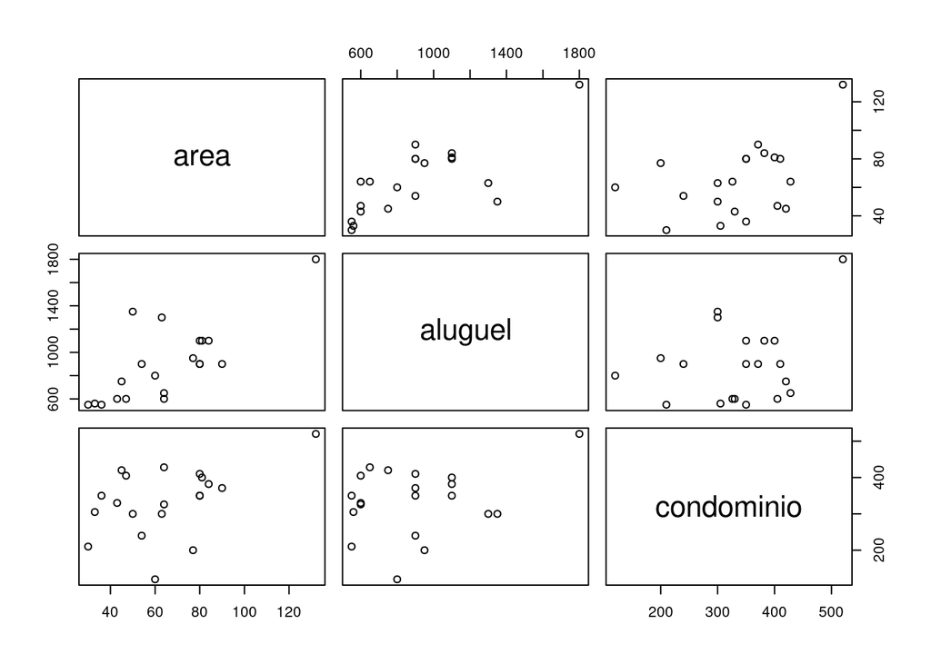

```r
plot(df_corr)
```

Podemos também construir um gráfico isolando apenas duas variáveis para explorar com mais detalhes:

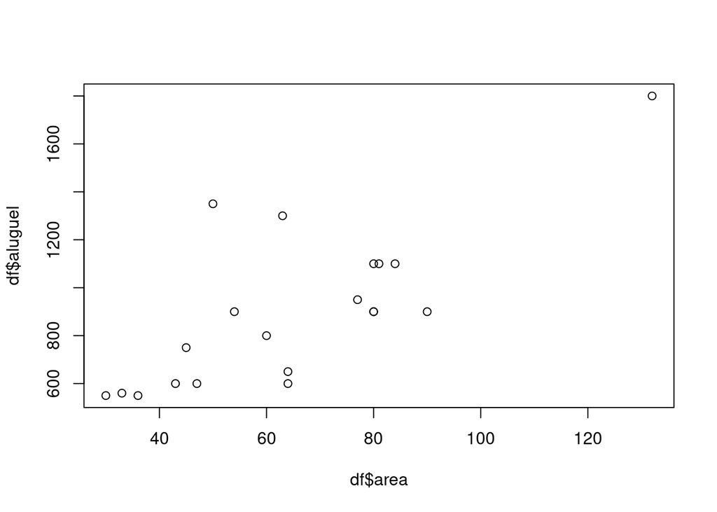

```r
plot(df$area, df$aluguel)
```

Este foram alguns exemplos simples de análises exploratórias. A complexidade da fase de análise exploratória vai depender do problema e das perguntas de pesquisa. Se for preciso, é possível fazer visualizações mais elaboradas e até algumas modelagens nesta fase.